# Montgomery County, PA - 911 Calls and COVID-19 Exploratory Data Analysis

**This is a work in progress. Please check in regularly for more updated plots. I try to update this page at least twice a week or more.**

## Historical Trends In 911 Calls From 2017 To Present For Select Complaints

### Fever

Very notable spike in calls at the beginning of 2020 compared to previous years. Scroll down to see a more focused plot specific for 2020 calls. *The ongoing drop in calls is concerning because it may imply people are now reluctant to call 911 and go to hospital for fear of getting exposed to COVID-19. We see a slight pick-up beginning of May, will be interesting to see if it starts to trend up again.*

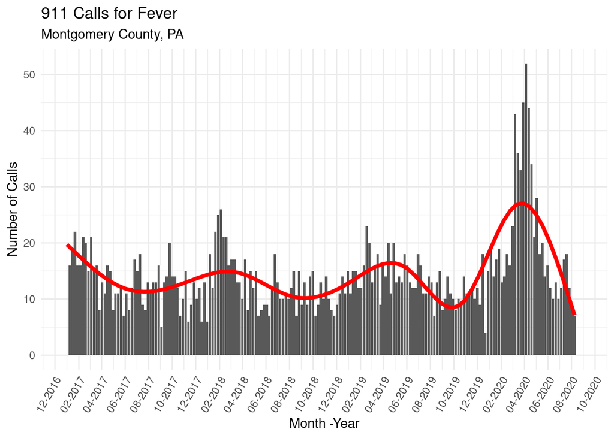

### Respiratory Emergencies

A very slight increase here which surprised me. I was expecting to see a much higher spike considering the initial understanding of SARS-CoV2 to be a respiratory virus.

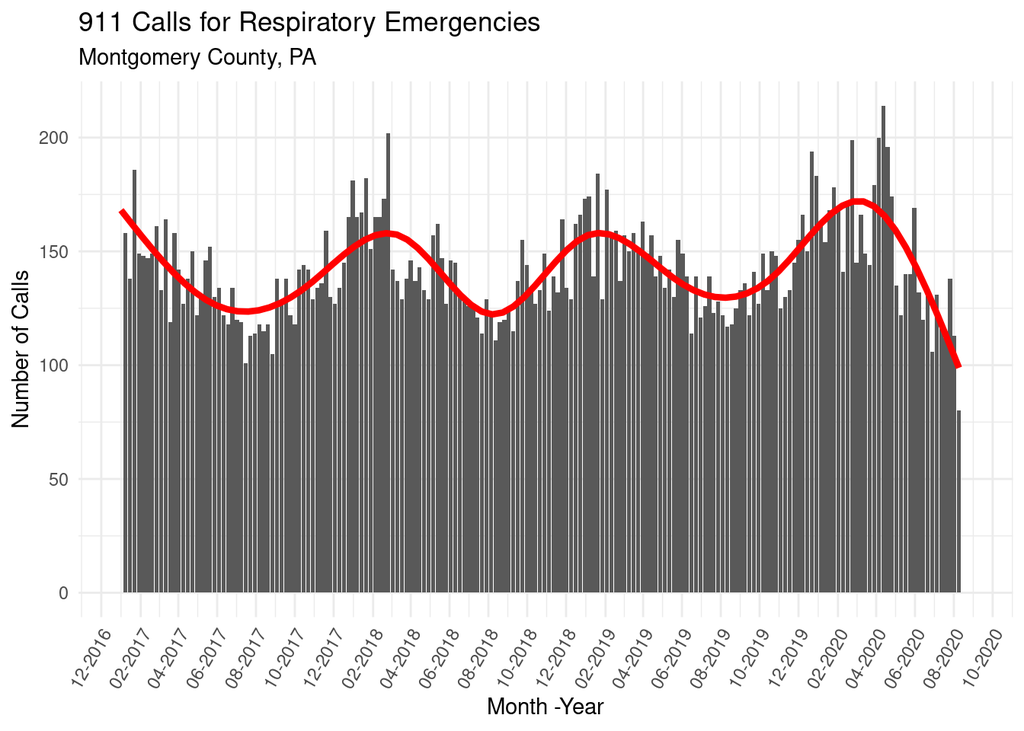

### Cardiac Emergencies

No noticeable spike here around COVID-19. However, the ongoing drop in calls is very concerning because it may imply people are now reluctant to call 911 and go to hospital for fear of getting exposed to COVID-19. This trend is now being reported in the media as well (see references section below)

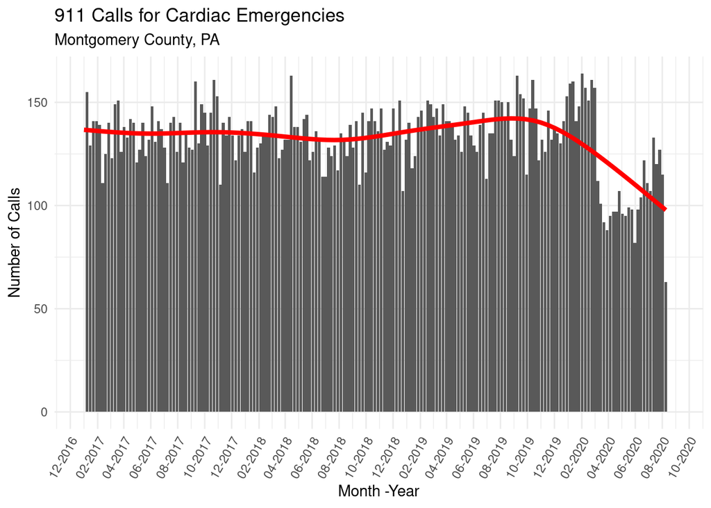

### Cardiac Arrests

Fairly consistent.

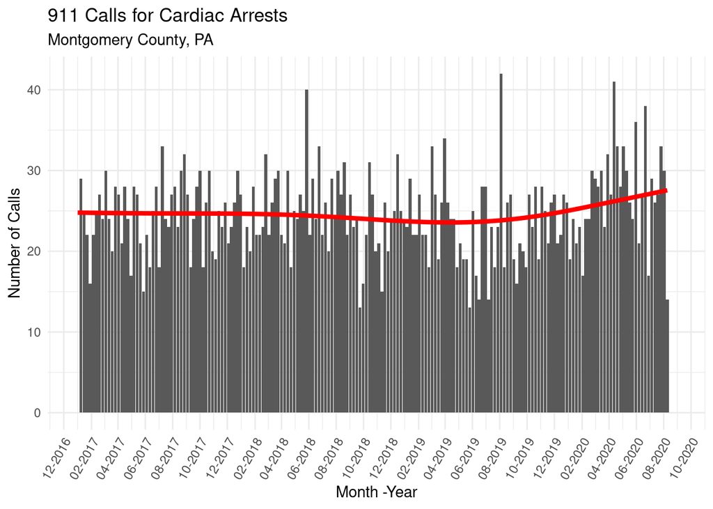

### Medical Alert Alarms

A noticeable increase in medic alert alarms starting late 2019, may be completely unrelated but would be interesting to triangulate and see if most of these are from nursing home locations?

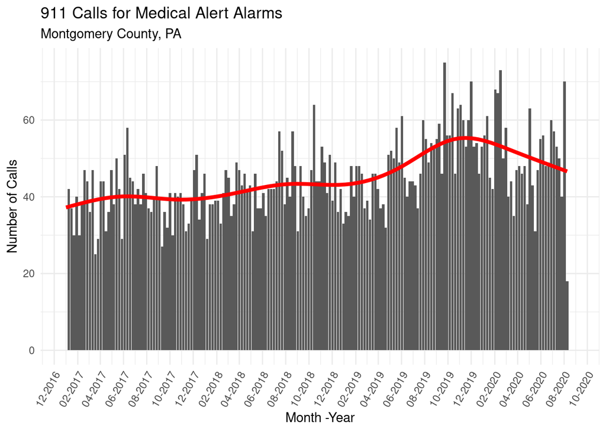

### All EMS related Calls

A drop off in all EMS calls, likely both a strong reflection of the quarantine measures and of people not wanting to go to hospital due to fear of contracting Sars-CoV-2? (See linked media article in the references section.)

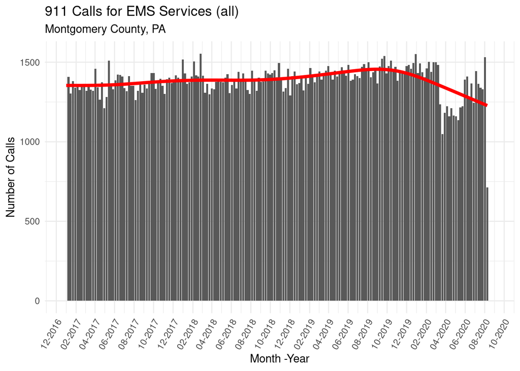

### Traffic-related incidents

A total drop off in 911 calls for traffic-related, likely a strong reflection of the quarantine measures, fewer people out and about.

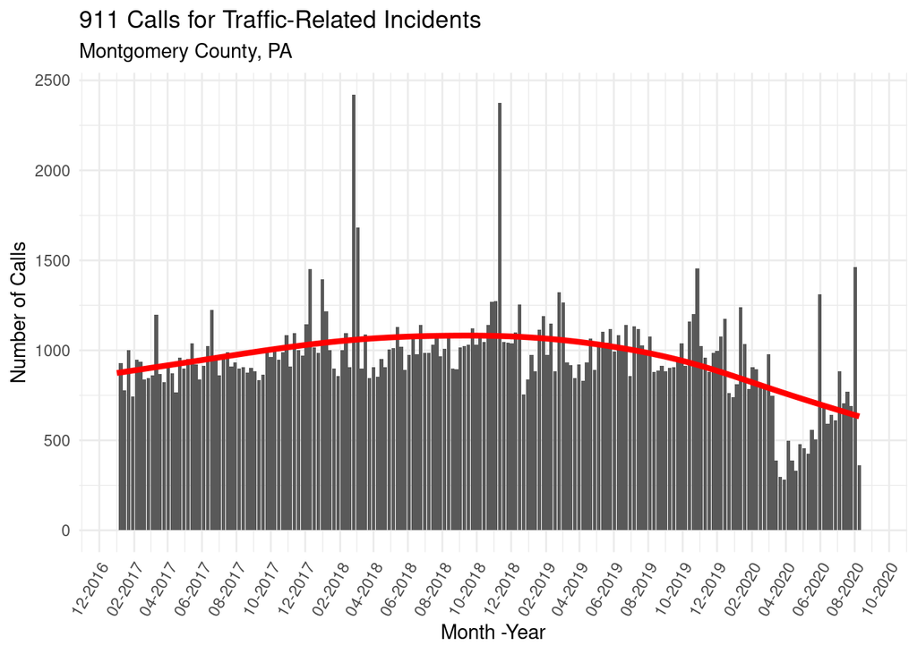

## SINCE PRESUMED START OF COVID-19 PANDEMIC

Narrowing down the focus on the data to just 2020, from around the presumed start of COVID-19 spread in the US.

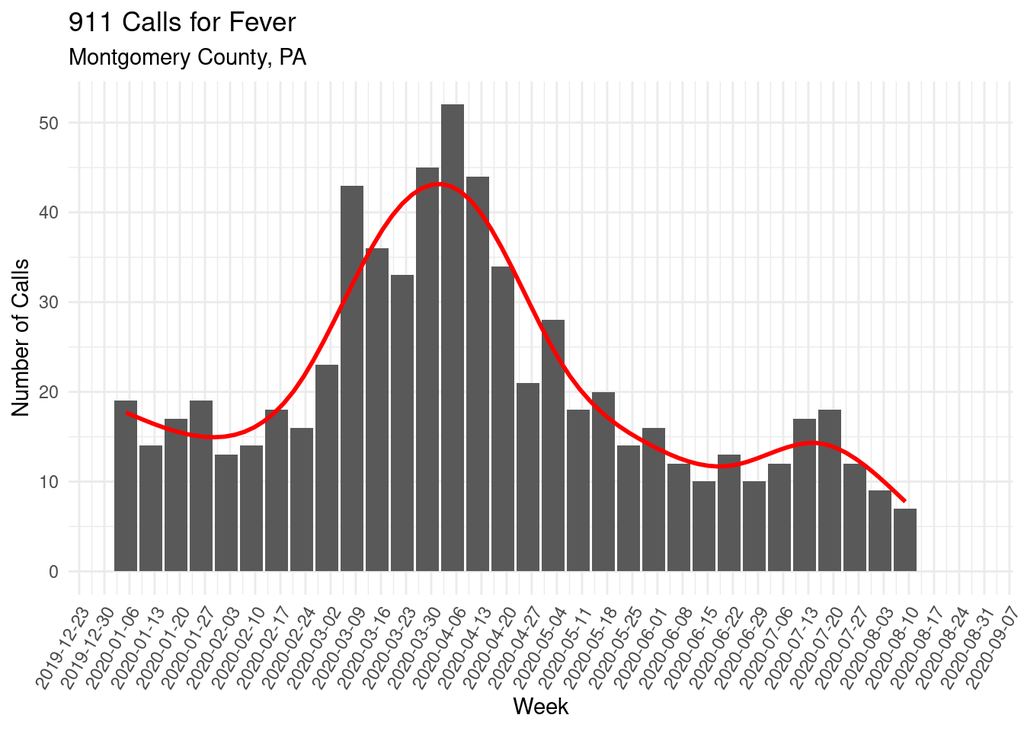

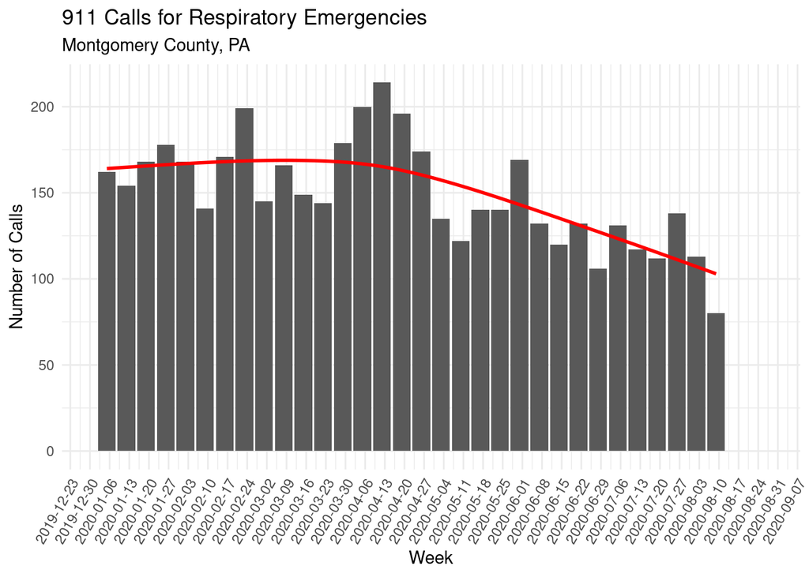

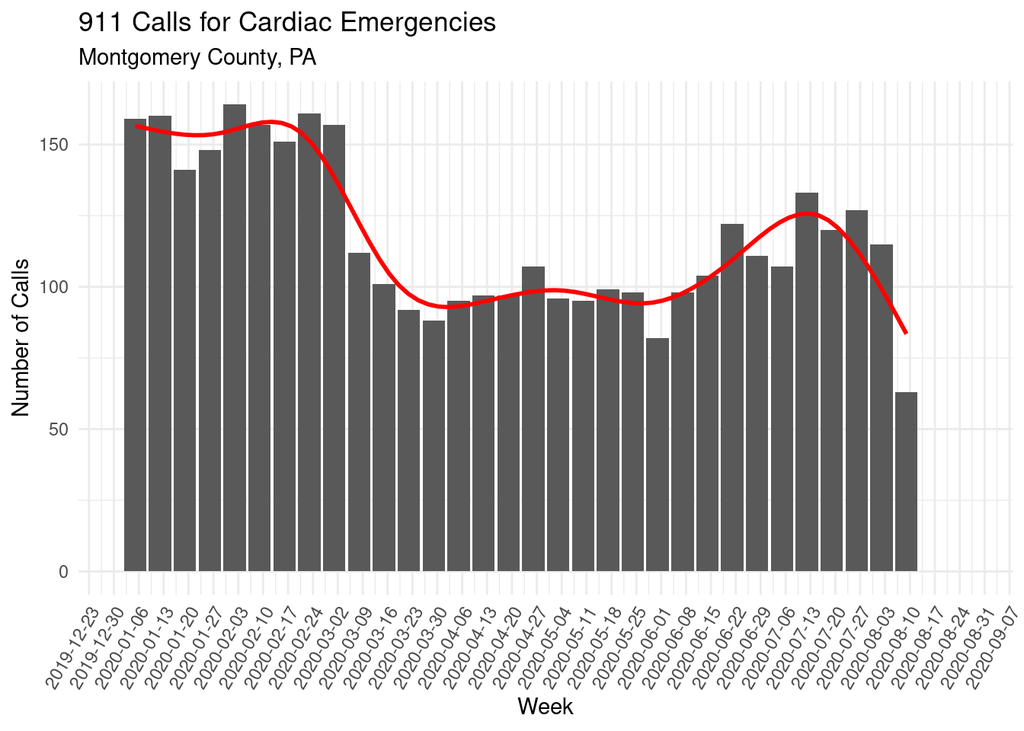

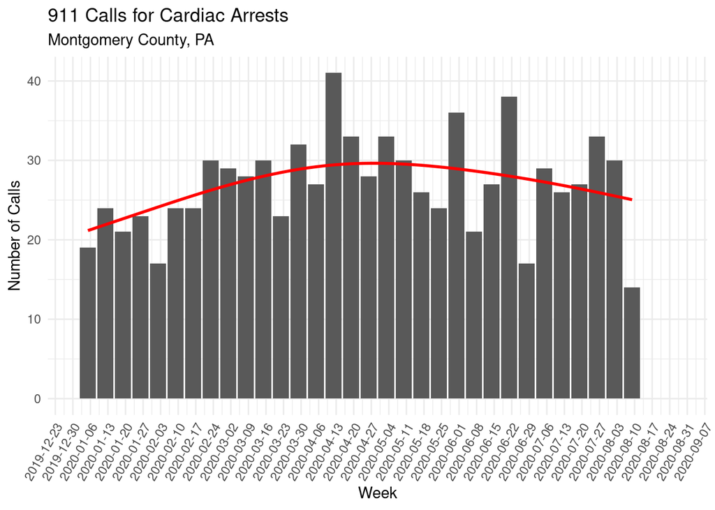

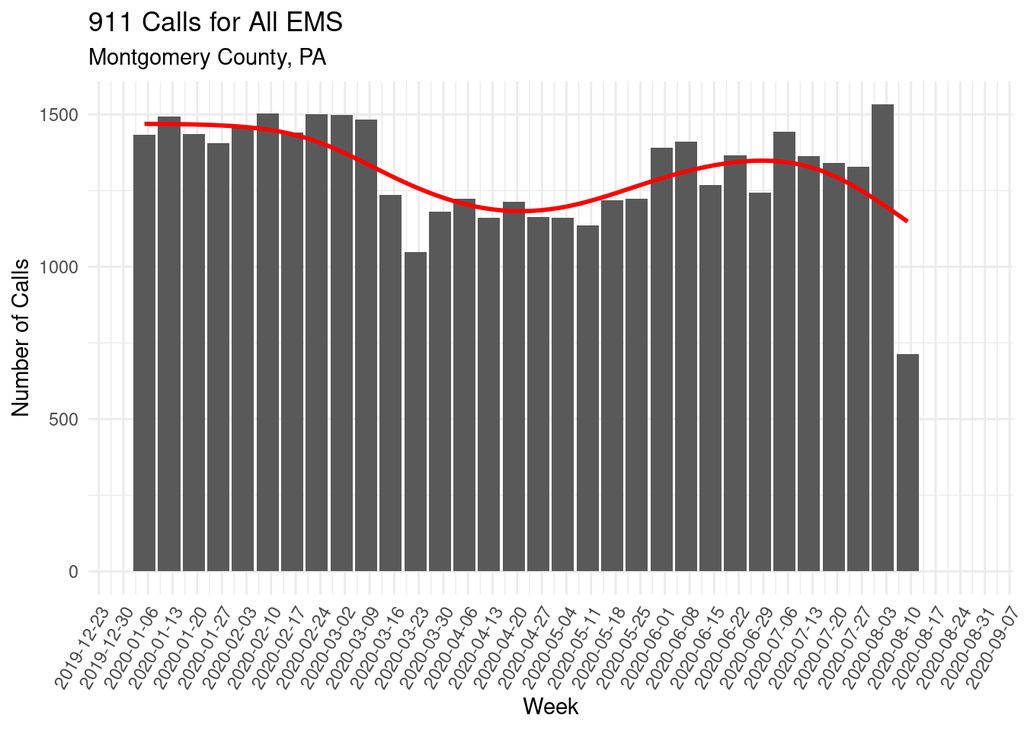

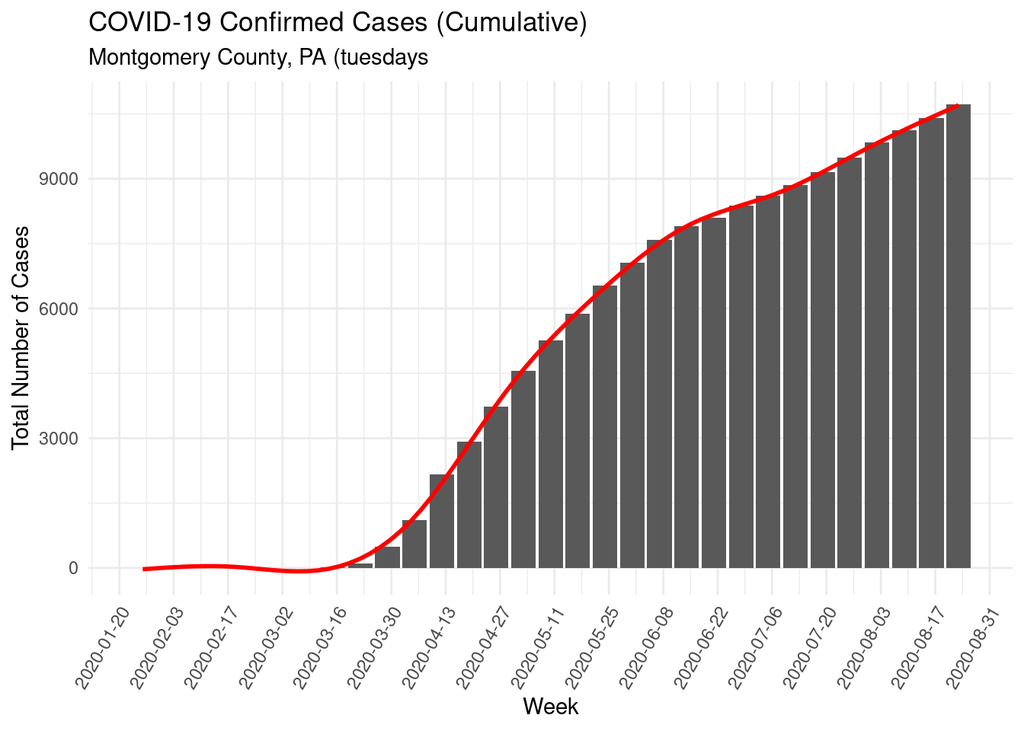

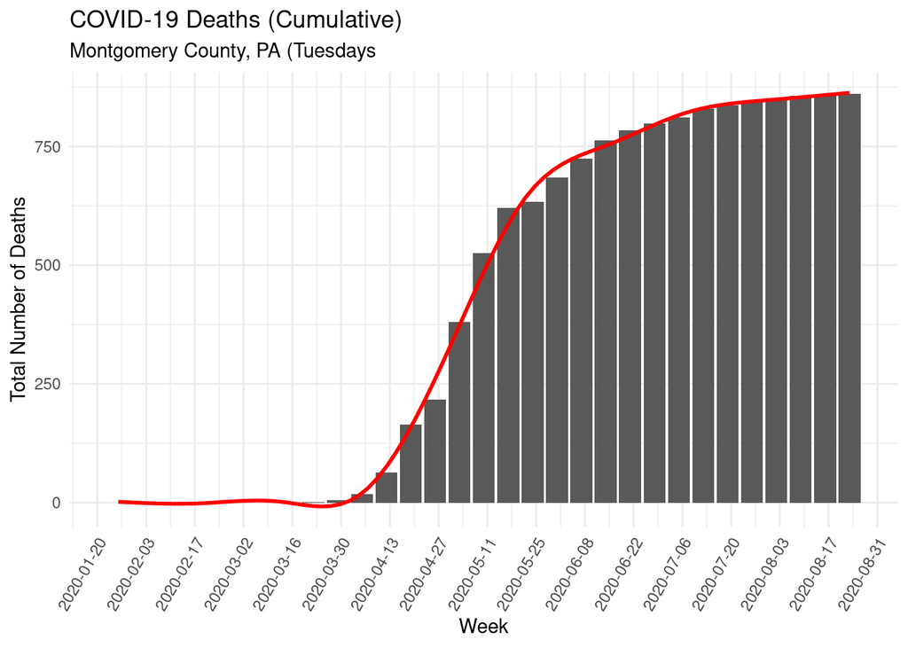

### Comparing Calls for Fever with Confirmed Cases

Exploring the correlation between number of calls for fever and number of confirmed cases we see a lag in the trends which may be indicative of the delay between when COVID-19 may have started affecting people in the area vs when confirmation of diagnosis (not an individual basis but from a general big-picture perspective)

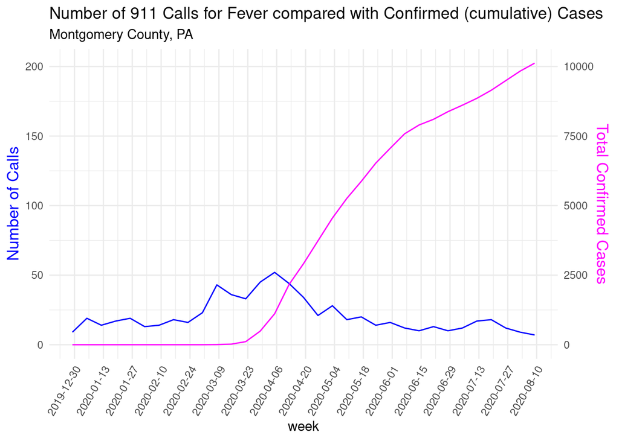

### DATA SOURCES:

- COVID-19 Case Numbers - [John Hopkins University](https://coronavirus.jhu.edu/map.html)
- Montgomery County EMS Data - Compiled and provided by [Mike Chirico](https://www.kaggle.com/mchirico/montcoalert)

## REFERENCES:

- [The New Pandemic Threat: People May Die Because They’re Not Calling 911](https://www.acc.org/latest-in-cardiology/articles/2020/04/22/13/36/the-new-pandemic-threat-people-may-die-because-theyre-not-calling-911-coronavirus-disease-2019-covid-19)
- [Eerie Emptiness Of ERs Worries Doctors: Where Are The Heart Attacks And Strokes?](https://www.npr.org/sections/health-shots/2020/05/06/850454989/eerie-emptiness-of-ers-worries-doctors-where-are-the-heart-attacks-and-strokes)

[My Github](https://github.com/marymlucas)

Last Updated:

```
## [1] "2020-08-27 07:31:49 EDT"
```